# Predicting real estate prices

David Utassy

2020-12-13

This is the output document of [**Project 2**](https://ceuedu-my.sharepoint.com/:x:/g/personal/orsosm_ceu_edu/ETc-Mf_JpbRPjSdH2t3d6ScB_z0xBrn8RmR4HtLx37_-xg?e=lDFYFj) for Web Srcaping in R. This project is created by David Utassy.

## Overview

The goal of this project to scrape different variables from the website [**www.ingatlan.com**](https://www.ingatlan.com), make some explanatory data analysis and try to predict the price of a custom flat with the given parameters.

Currently this is just a very basic solution, but at the end of this markdown I will mention further possible improvements that I am planning to make in the future.

## Process

In this section I will conclude step-by-step the process of the project.

### Getting the links from one page

The following code snippet contains the a function that makes it possible to get the link of all the real estates on the page given in the argument as a URL.

```r
get_links_from_page  <- function(my_url) {
  print(my_url)
  t <- read_html(my_url)
  boxes <- t %>%
    html_nodes('.listing__card')
  x <- boxes[[1]]

  boxes_df <- lapply(boxes, function(x){
    t_list <- list()
    t_list[['link']] <- paste("https://ingatlan.com/",x %>%html_nodes('a') %>% html_attr('href'), sep="")

    return(data.frame(t_list))
  })

  df <- rbindlist(boxes_df)

  toDelete <- seq(0, length(df$link), 2)
  df <-  df[-toDelete, ]

  return(df)
}
```

### Scrape with the given searchterm the given number of pages

In order to get a lot of real estates, we need to scrape several pages with an adjustable search term. The following function gets the number of we want to scrape and a searchterm in which we are able to filter for different kind of real estates.

```r
get_pages <- function(number_of_pages_to_download, searchterm) {
  # create links
 links_to_get <- paste0('https://ingatlan.com/lista/',searchterm, '?page=', seq(1, number_of_pages_to_download))
 ret_df <- rbindlist(lapply(links_to_get, get_links_from_page))
  return(ret_df)
}
```

### Get data from each and every real estate we have

Using the function above we have a list of URLs that leads to the website of unique real estate on ingatlan.com. In order to get the date from this pages I implemented the following function. It scrapes 50 different variables for every advertisement, and returns into a dataframe.

```r
process_flats  <- function(my_link) {
  print(my_link)
  t <- read_html(my_link)
  data_list <- list()

 tkeys <- t %>% html_nodes('.parameter-title') %>% html_text()
 tvalue <- t %>% html_nodes('.parameter-value') %>% html_text()
 if (length(tkeys) ==length(tvalue)) {
   print('good base info data')
   for (i in 1:length(tkeys)) {
     data_list[[  tkeys[i]  ]] <- tvalue[i]
   }
 }

 tkeys <- t %>% html_nodes('td:nth-child(1)') %>% html_text()
 tvalue <- t %>% html_nodes('td+ td') %>% html_text()
 if (length(tkeys) ==length(tvalue)) {
   print('good base info data')
   for (i in 1:length(tkeys)) {
     data_list[[  tkeys[i]  ]] <- tvalue[i]
   }
 }

  return(data_list)
}


##Use these function calls to scrape!

#links <- get_pages(50, 'elado+lakas+ujszeru+felujitott+jo-allapotu+xiv-ker')
#links_list <- as.list(as.data.frame(t(links)))

#output_df <- rbindlist(lapply(links_list, process_flats), fill = T)

#write.csv(output_df, file = '/Users/utassydv/Documents/workspaces/CEU/my_repos/ingatlan_com_scraper/data/raw/raw_1000.csv')
```

### Data Cleaning

In order analyze the data we need to clean it, especially as we scraped values as text. As a first step for this assignment I keep only the very basic variables which most of the advertisement have. These variables are floorspace, number of rooms and price. In bullet point I conclude the cleaning steps that I have made:

- read in raw data
- drop not needed columns
- rename columns
- drop observations with missing values
- extract meaningful quantitative variable from the text we scraped
- write out clean data

```r
raw_df <- read.csv(file = '/Users/utassydv/Documents/workspaces/CEU/my_repos/ingatlan_com_scraper/data/raw/raw_1000.csv')


#remove not needed columns
keep_cols <- c("Alapterület", "Szobák.száma", "X.Hitelre.van.szükséged..Kalkulálj..")
raw_df <- raw_df %>% select(keep_cols)

#rename columns
raw_df <- raw_df %>% rename(
    floorspace = Alapterület,
    num_rooms = Szobák.száma,
    price = X.Hitelre.van.szükséged..Kalkulálj..
    )

#drop observations with missing values
raw_df <- raw_df[complete.cases(raw_df), ]


#get meaningful numbers from text

#floorspace
raw_df <-  separate(raw_df, floorspace, " ",
                     into = c("floorspace"))

#price
raw_df <-  separate(raw_df, price, " ",
                     into = c("clean"))
raw_df <-  separate(raw_df, clean, ",",
                     into = c("decimal", "remaining" ))

raw_df[is.na(raw_df)] <- 0
raw_df$price <- as.numeric(raw_df$decimal) + as.numeric(raw_df$remaining)/10
raw_df <- raw_df %>% select(-c("decimal", "remaining"))

#number of rooms
raw_df<-  separate(raw_df, num_rooms, " fél",
                     into = c("clean"))
raw_df <- raw_df %>% mutate(across(where(is.character), str_remove_all, pattern = fixed(" ")))
raw_df <-  separate(raw_df, clean, "\\+",
                     into = c("num_whole_rooms","num_half_rooms"))
raw_df[is.na(raw_df)] <- 0
raw_df$num_rooms <- as.numeric(raw_df$num_whole_rooms) + as.numeric(raw_df$num_half_rooms)/2

clean_df <-  raw_df

write.csv(clean_df, file = '/Users/utassydv/Documents/workspaces/CEU/my_repos/ingatlan_com_scraper/data/clean/clean_1000.csv')
```

### Explanatory Data Analysis

For an explanatory data analysis I plotted the histogram and made a summary of the variables I have. From the following table it can be seen, that the variables are skewed but in an acceptable way. I also experimented with the ln() transformation of the variables, but the improvement does not worth the modification.

[figure not shown]

| variable | mean | median | std | iq_range | min | max | skew | numObs |
| --- | --- | --- | --- | --- | --- | --- | --- | --- |
| Price [million HUF] | 46.37 | 39.9 | 24.52 | 24.9 | 12.3 | 199 | 2.26 | 916 |
| Floorspace [m2] | 61.69 | 54.0 | 27.27 | 25.0 | 11.0 | 194 | 1.72 | 916 |
| Number of rooms | 2.28 | 2.0 | 0.96 | 1.5 | 1.0 | 7 | 1.08 | 916 |

### Creating a model

I have tried 4 different models on my dataset in order to predict price.

Model 1: $price^{E}$ = $\alpha$ + $\beta$$floorspace$

Model 2: $price^{E}$ = $\alpha$ + $\beta_{1}$$floorspace$ + $\beta_{2}$${floorspace}^{2}$

Model 3: $price^{E}$ = $\alpha$ + $\beta_{1}$$floorspace$ + $\beta_{2}$${floorspace}^{2}$ + $\beta_{3}$$number_of_rooms$

Model 4: $price^{E}$ = $\alpha$ + $\beta_{1}$$floorspace$ + $\beta_{2}$${floorspace}^{2}$ + $\beta_{3}$$number_of_rooms$ + $\beta_{4}$${number_of_rooms}^{2}$

I made the evaluation of them by plotting them (if possible) and with a regression summary table. From the two plots below it can be seen that the simple linear regression is already a good model, but the quadratic model looks like a bit better.

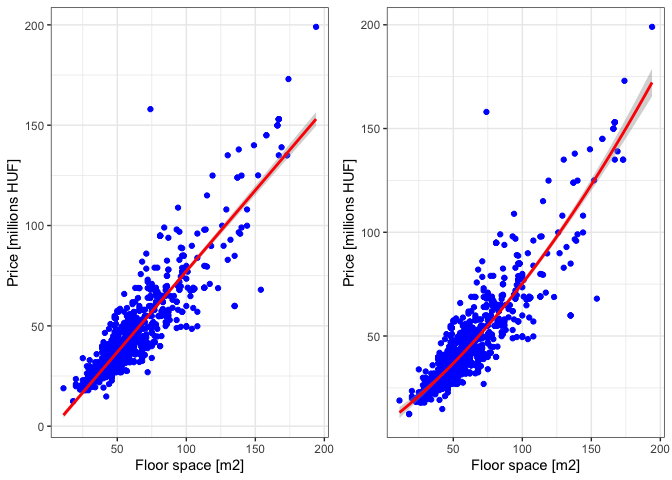

Statistical models

|  | Model 1 | Model 2 | Model 3 | Model 4 |
| --- | --- | --- | --- | --- |
| (Intercept) | -3.37* | 7.44* | 7.62* | 7.15* |
|  | [-5.79; -0.95] | [3.65; 11.22] | [ 3.73; 11.51] | [ 2.65; 11.65] |
| floorspace | 0.81* | 0.50* | 0.47* | 0.43* |
|  | [ 0.76; 0.85] | [0.38; 0.61] | [ 0.31; 0.63] | [ 0.25; 0.61] |
| floorspace_sq |  | 0.00* | 0.00* | 0.00* |
|  |  | [0.00; 0.00] | [ 0.00; 0.00] | [ 0.00; 0.00] |
| num_rooms |  |  | 0.50 | 2.05 |
|  |  |  | [-1.45; 2.45] | [-2.83; 6.94] |
| num_rooms_sq |  |  |  | -0.25 |
|  |  |  |  | [-1.22; 0.71] |
| R<sup>2</sup> | 0.80 | 0.81 | 0.81 | 0.81 |
| Adj. R<sup>2</sup> | 0.80 | 0.81 | 0.81 | 0.81 |
| Num. obs. | 916 | 916 | 916 | 916 |
| RMSE | 10.86 | 10.62 | 10.62 | 10.62 |

* Null hypothesis value outside the confidence interval.

According to the regression summary table I have decided to use Model 1. as according to R2 the following models are just sightly better, therefore we should enjoy the straightforward interpretation of Model 1.

### Prediction

For the prediction I used Model 1. Therefore I was able to implement a function that takes in a floorspace as an argument and returns the predicted price of the real estate. Please note that out model, therefore prediction is influenced by the input dataset we have. In our case I filtered for already used flats for sale in the 14. district of Budapest. For prediction interval, and external validity further analysis needed!

```r
#Prediction lets use Model1
predict_price <- function(floorspace) {
  return(reg1$coefficients[1] + floorspace*reg1$coefficients[2])
}
#If we have a flat which is 55m2 in the 14. district
predict_price(55)
```

```
## (Intercept)
##    40.97688
```

Our predictor function returned the following price (in millions [HUF]) for a flat that has 55 m2 floorspace.

## Further improvement possibilities.

Because the focus of this assignment and lack of time there are lot of improvement possibilities left in this project:

- Use more variable from the scraped data (only 3 used out of almost 50)
- Scrape the summary part for every real estate, make sentiment analysis and entity recognition for more variables.
- Use image recognition to identify the quality of the real estate from the pictures and add more variables
- Scrape all the data from Budapest
- Build an automated scraper infrastructure that scrapes the industry regularly and builds dashboard from it
- Get geolocation, use it to produce distance to city center variable
- Get nearest public transportation stations

## Summary

This project managed to scrape and analyze almost 1000 flats for sale in Budapest, build a model on it and predict price for custom flats. As it has been already mentioned this project opened the gate for many further improvement which I am planing to do in the future.